# Main Model

Nick Strayer

March 26, 2015

## Check for the existance of needed datafiles.

If the files are not present, then run their corresponding scripts and generate them.

The corresponding R Markdown scripts associated with these files can be found on RPub:

- [Solar Data Cleaning](http://rpubs.com/nstrayer/64339)
- [Thermocline Model](http://rpubs.com/nstrayer/thermoclineModel)
- [Mysocline Depth Model](http://rpubs.com/nstrayer/64310)

```r
setwd("/Users/Nick/mysisModeling") #Locate ourselves in the computer.

#Check for solar data
if(!file.exists("data/light_day_moon_hour.csv")){ source("dataGen/solarData.r") }

#Check for thermocline data
if(!file.exists("data/Depth_Thermocline_Hour.csv")){ source("dataGen/thermoclineLevels.r") }

#Mysocline data
if(!file.exists("data/mysocline_hour.csv")){ source("dataGen/depthModel.r") }

#Mysocline data
if(!file.exists("data/FoodAvail_Hour.csv")){ source("dataGen/foodAvailability.r") }

#Read in the data now.
depthData = read.csv("data/mysocline_hour.csv")$x
foodCurve = read.csv("data/FoodAvail_hour.csv")
foodAvail = foodCurve$foodAvail
foodVar   = foodCurve$variability
```

## Class and method declarations:

I have chosen to use the S4 object oriented programing style. The details are minor but more info can be found [here](https://www.stat.auckland.ac.nz/~stat782/downloads/08-Objects.pdf).

### Set up the mysis class:

This basically is a digital mysis that simplistically holds a couple of peices of information and upon which the model will act.

```r
setClass("mysis",
         representation(
           energy    = "numeric",    # The energy reserves are a numeric value
           migrating = "logical",    # If mysis is migrating is a logical value
           alive     = "logical",    # Alive still?
           depth     = "numeric"),
         prototype(
           energy    = 0,            # The default instantiated mysis starts with zero energy...
           migrating = FALSE,        # and not migrating...
           alive     = TRUE,         # alive
           depth     = 100),         # and at the bottom.
         )

#Set the show method, basically how we want the program to display the info about the mysis on calling.
setMethod("show", "mysis",
          function(object){
            if (object@alive){
              print(object@energy)
              print(object@migrating)
              print(object@depth)
            } else {
              print("dead")
            }
          })
```

**Real quick we need to make a model for decisions to migrate based upon condition:**

The form of this model is a logistic curve: $f(x) = \frac{1}{1 + e^{-k(x - m)}}$ Where **$k$** is an indicator of steepness, and **$m$** is the midepoint of the curve.

```r
migrationProb = function(condition){ #I am choosing to leave the random roll outside of script for continuity, could be changed
  m = 120 #value of curve midpoint
  k = 0.03 #steepness of curve
  x = condition

  dist = 1/(1 + exp(-k* (x - m)))
  return(1 - dist)
}
```

### The decision tree model:

This is a stochastic model, meaning it utilizes randomness to simulate the real world.

The function of the decision tree is such:

```r
rewardUnits = .7

setGeneric( "nextTime", function(object, ...){standardGeneric("nextTime")})
setMethod("nextTime","mysis",
          function(object, foodAvail, foodVar, time){       #Takes in the mysis object and the ratio of food quality at a given time.

            #Run the draws:
            migrationDraw   = runif(1) #random number between 0 and 1, this will be used for the migration decision
            migrationDraw_2 = runif(1) #draw for second migration decision, this time compared to logistic curve
            predationDraw   = runif(1) #" " to see if killed by predation
            #Lets set some constants real quick:
            migrationCost = 21       #How many energy units the mysis use up migrating
            migrationRisk = 0  #We don't really need to simulate predation.
            stayRisk      = 0
#             migrationRisk = 0.0001   #Chance of being eaten if migrating
#             stayRisk      = 0.00001  #Chance of being eaten if they stay on the bottom
#
            #Energy rewards:
            migrationReward = rnorm(1, (rewardUnits*(1 + foodAvail)), foodVar)
            stayReward      = migrationReward * .2
            threshold = 0.2  #Let's make sure that the benthic reward can never drop below a threshold.
            if(stayReward < threshold){
              stayReward = threshold
            }

            sunset  = 18 #hardcode sunset, fill this with real data later.
            sunrise = 7
            conditionCurve = migrationProb(object@energy)

            if (object@energy <= 0){ #did the mysis starve?
              object@alive = FALSE
              object@energy = 0
            }
            #if the mysis is in good condition use standard migration chance, if bad use 1 - chance
            if ((time %% 24 == sunset + 1)&&(object@alive)){
              if (migrationDraw < foodAvail) {
                object@migrating = migrationDraw_2 > conditionCurve
                object@energy = object@energy - migrationCost
              } else {
                 object@migrating = FALSE
              }
            } else if (time %% 24 == sunrise){ #bring them back down at sunrise.
              object@migrating = FALSE
            }

            #Here is the decision tree:
            if (object@alive){ #If the mysis is alive let's run the decision tree
              if (object@migrating){
                object@depth = depthData[time] #Grab the mysocline limit at this hour

                if (predationDraw > migrationRisk){ #The mysis evades predation
                  object@energy = object@energy + migrationReward
                } else { #Mysis is eaten
                  object@alive = FALSE
                }
              } else { #The mysis didn't migrate
                object@depth = 100

                if (predationDraw > stayRisk){ #The mysis evades predation
                  object@energy = object@energy +  stayReward
                } else { #Mysis is eaten
                  object@alive = FALSE
                }
              }
            }
            object} #Return the mysis
          )
```

### Testing it:

Now that the model is all set up can run it over a small subset of the eventual numbers (~10,000 mysids over 8,700 hours) and see what results we get.

```r
mysids = NULL
numOfMysids = 250
mysisNames = paste("mysis",(seq(1,numOfMysids)), sep = "")

for (i in 1:numOfMysids){
  initialenergy = rnorm(1,150,25) #draw initial energy from normal dist centered at 30 with stdev of 5.
  mysids = c(mysids, new("mysis", energy = initialenergy) )
}
```

… and now we can run the model on those mysids:

```r
migrations = NULL #Initialize some dataframes to keep track of the migrations and conditions values for the mysids.
conditions = NULL
alive      = NULL
hours = 1:(24*365) #150 days
for (mysid in mysids){ #loop through the mysis
  migration = NULL
  condition = NULL
  for (i in hours){
    mysid    = nextTime(mysid, foodAvail[i], foodVar[i] , i)
    migration = c(migration, mysid@depth)
    condition = c(condition, mysid@energy)
    if (i == length(hours)) { alive = c(alive, mysid@alive)}
  }
  migrations = cbind(migrations, migration) # add to the object of migrations.
  conditions = cbind(conditions, condition)
}
```

## What do we have?

Let’s plot this small run to see what kind of behavior we are getting.

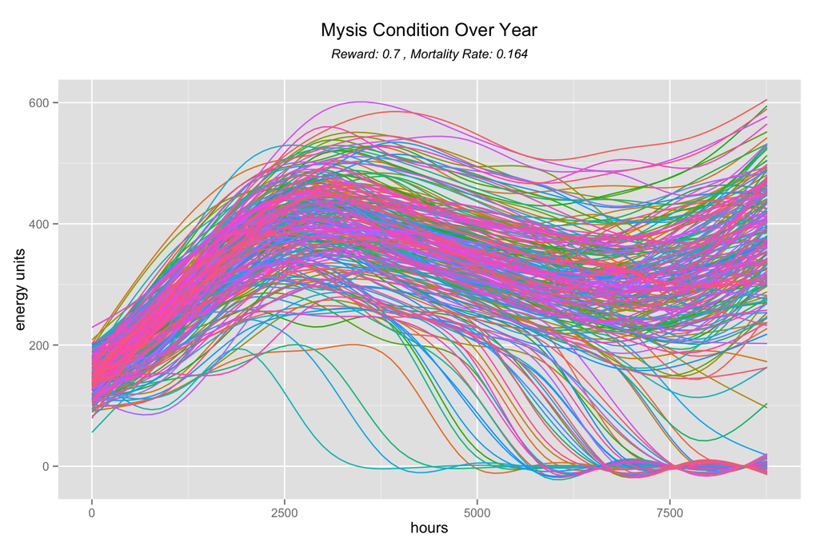

## What are the patterns of the mysis that survived?

By plotting a histogram of the days migrated by surviving mysids we can get a glimps into the more succesful strategies employed.

First we make a function that takes in migration height data and returns how many days the mysid migrated:

```r
howManyMigrations = function(mysid){return(365 - sum(mysid[seq(19,(365*24), 24)] == 100))}
```

Next, we run this through the mysids that survived.

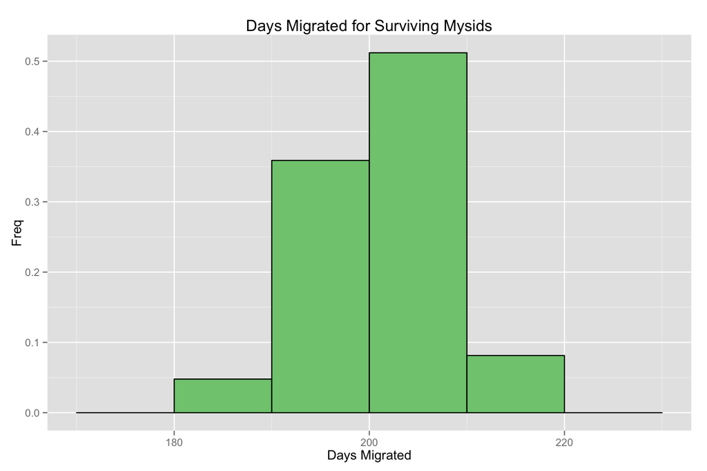

```r
mysidsWhoLived = mysidsWhoDied == FALSE

daysMigrated = NULL

for(indv in mysisNames[mysidsWhoLived]){
  daysSurvived = howManyMigrations(migrations_df[[indv]])
  daysMigrated = c(daysMigrated, daysSurvived)
  }

survivingMysis = data.frame(daysMigrated)

ggplot(survivingMysis, aes(x = daysMigrated)) +
  geom_histogram(aes(y=..count../sum(..count..)), color = "black", fill = "#7fc97f", binwidth = 10) +
  labs(title = "Days Migrated for Surviving Mysids", x = "Days Migrated", y = "Freq")
```